# README

## Background and Introduction

The motivation for all of this came from the following 3Blue1Brown video presenting "The inscribed square/rectangle problem, solved using Möbius strips and Klein bottles."

https://www.youtube.com/watch?v=IQqtsm-bBRU

further reading can be found here:

https://www.quantamagazine.org/new-geometric-perspective-cracks-old-problem-about-rectangles-20200625/

https://arxiv.org/pdf/2005.09193 (THE RECTANGULAR PEG PROBLEM - JOSHUA EVAN GREENE AND ANDREW LOBB)

I also ventured into my own area of this analysis applied to networks instead of curves.

## Structure

- customfunctions/
  - contains four custom MATLAB functions to do four essential tasks to make the reproduction of the tests easy to piece together
    - "fdistances.m" INPUT: n pairs of coordinates OUTPUT: nxn distance matrix
    - "finterpolate.m" INPUT: n pairs of coordinates, resolution OUTPUTS: defines the curve at a higher resolution than input curve
    - "fmidpoints." INPUT: n pairs of coordinates, form="Matrix" or "List" OUTPUTS: the midpoints of all pairs in matrix or list form
  - all of above are collated and a base analysis is outputted by "fplot_topology.m" which works for any coordinate pair input
- functiontopologies/
  - contains analysis of shapes generated by functions
- networktopologies/
  - contains analysis of networks generated from Laplacian from py/
- polygon_topologies/
  - contains analysis of shapes generated by the coordinate output of the polygon drawn from PDE_modeller application from MATLAB's Partial Differential Equation add-on
- pde_polygons/
  - contains the direct output code for the shapes generated from the PDE_modeller application
- py/
  - contains the python code to generate, test and output information for networks

## Polygons examples:

### Heart

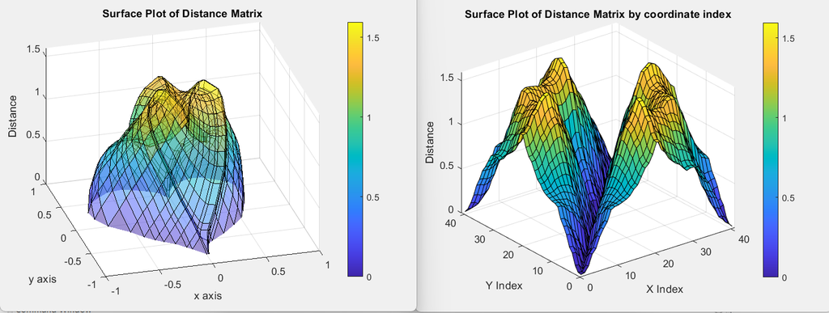

#### Star

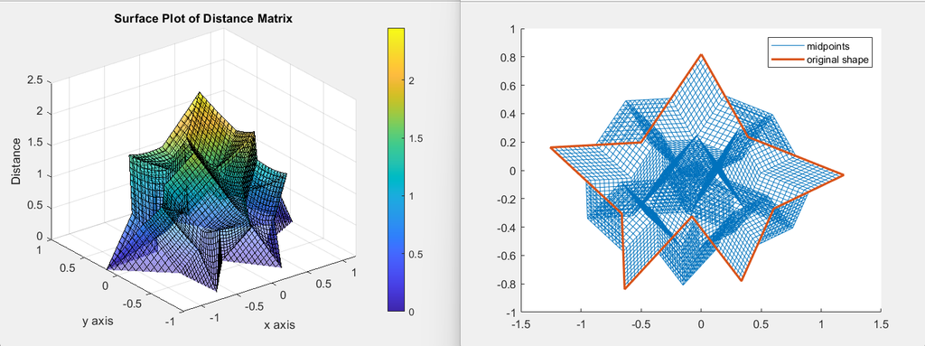

### Functions Examples

#### Circle

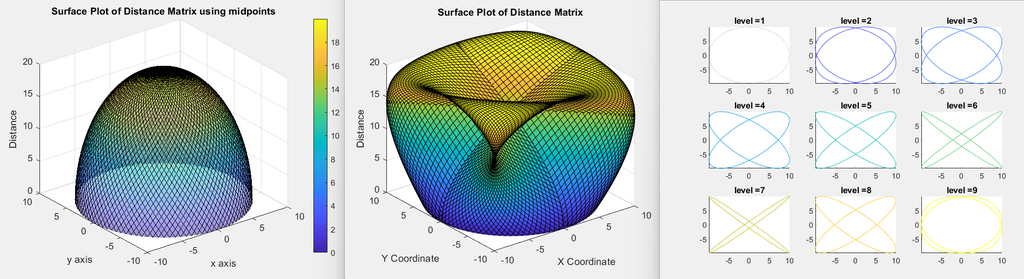

#### Hourglass

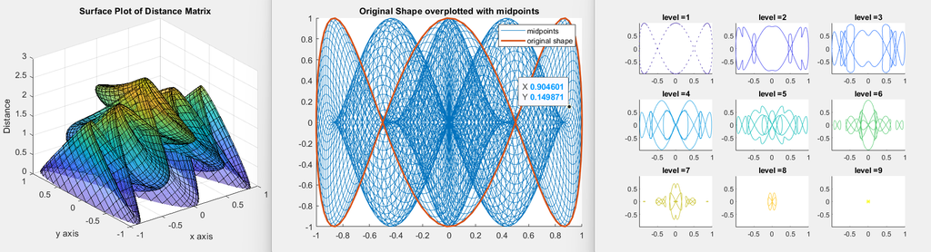

#### sin(2*pi)

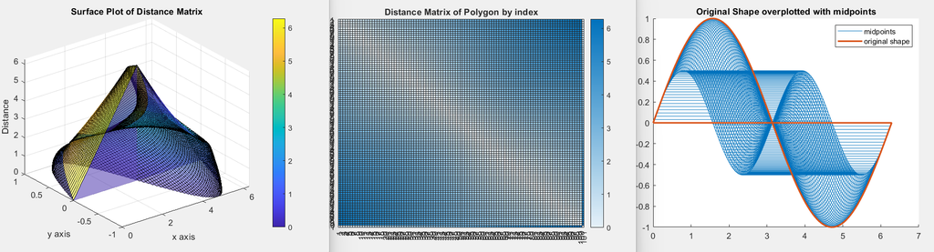

## Networks

Network construction was done in python, constructed from the following principles:

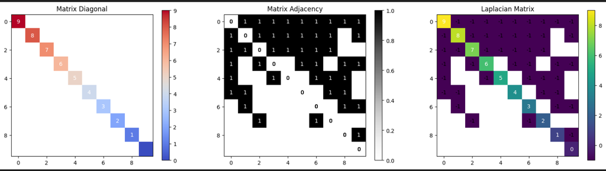

#### 50-node network

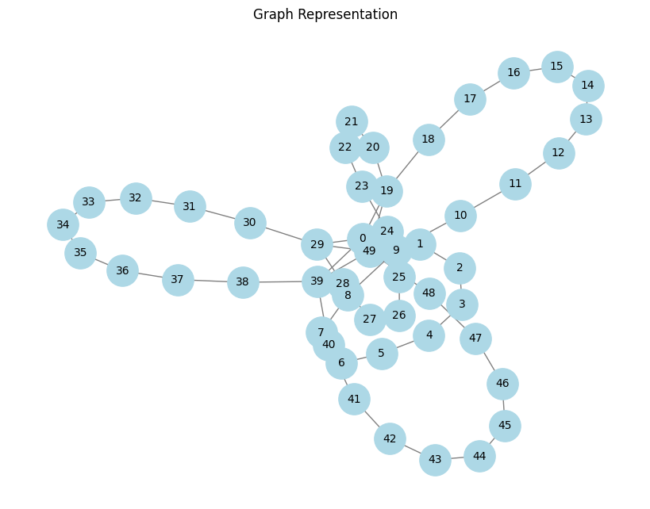

circlular representation:

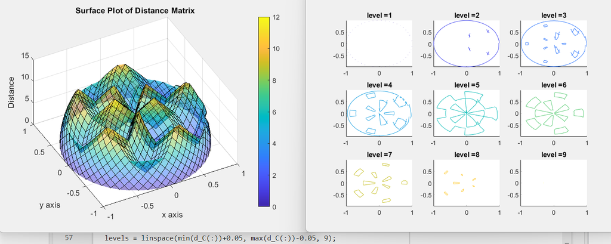

spectral representation:

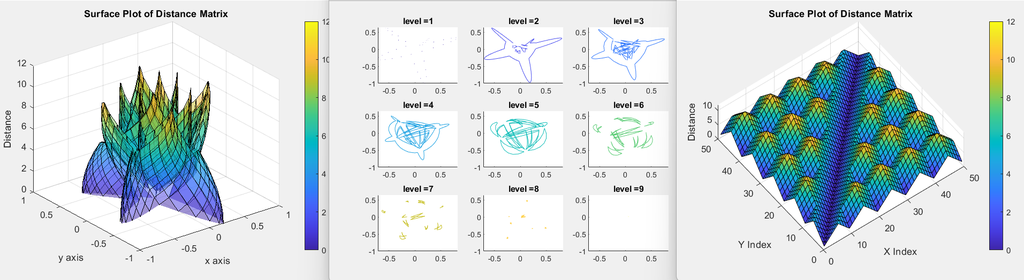